# A3: SPL Library Checkouts

### Introduction

The dataset shows entries of books checked out from 2022 to 2023. I’m choosing analyze the trends seen consistently across the year, or certain values that seem important, because I think that within a large dataset like this, it’s important to summarize the data so that it can grasp the bigger picture.

### The Dataset

The data was collected and published by the Seattle Public Library. With the data, it was collected from January 2022 to January 2023, spanning over one year. It recorded every checkout with every media type, including physical books, ebooks, audiobooks, sound disks, and more. The data was collected straight from the library’s system, as they have direct access to the checkout data. This data was collected because through the Open Data Program, the Seattle Public library wanted to increase quality of life for Seattle residents, increasing transparency, accountability and comparability, and promoting economic development and research. In addition, it would also improve performance management. It participates in the mission to improve public understanding of information concerning their communities, empowers city employees to be more effective, better coordinated internally, an able to identify opportunities to better serve the public, and encourage the development of innovative technology solutions that improve quality of life. Because the data is based only on items checked out at the library, there’s not many ethical questions needed to be considered when working with the data. Some limitations with the dataset are the short timeframe that it was collected in, as it doesn’t show the longterm trends as well as it would if the dataset was collected within a longer timeframe.

### First Trends Over Time Chart

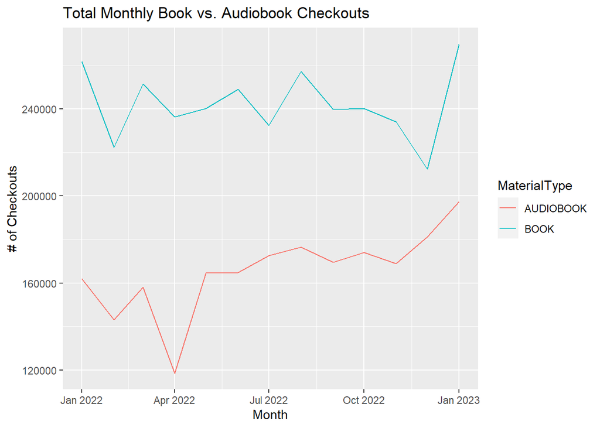

### Second Trends Over Time Chart

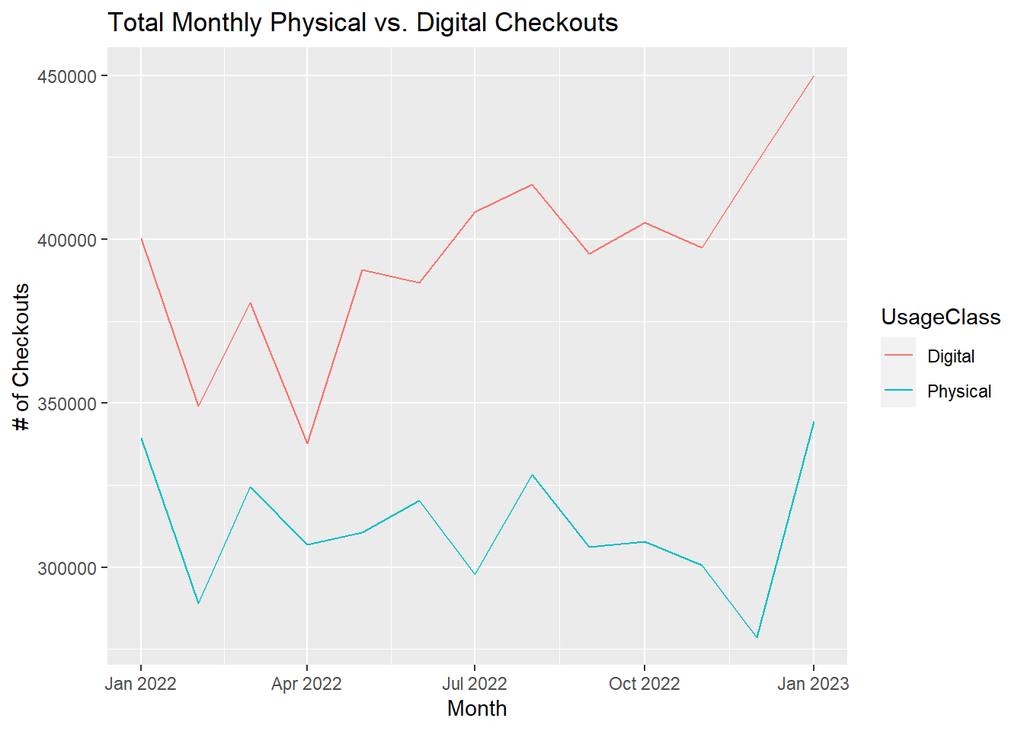

### Your Choice

For my third chart, I decided to do a bar plot representing the most significant materials that were checked out throughout the year. Because of the vast range between the least and most amount of material types checked out, the plot was most useful when the values were filtered to material types that had 5000 checkouts or more. Looking at the chart, it’s clear to see that the most popular material type is books, while eBooks and audiobooks follow behind as second and most popular.

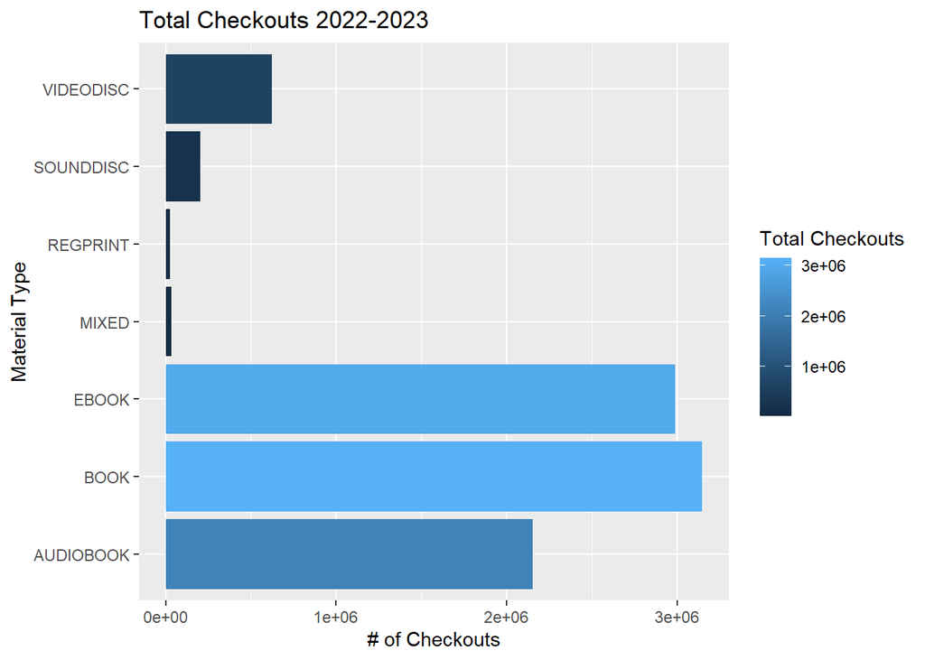